# Data Analysis with Python copy

[figure not shown]

## Overview of Covered Content

```python
import numpy as np
import pandas as pd
import matplotlib.pyplot as plt

%matplotlib inline
```

```python
sales = pd.read_csv('sales_data.csv', parse_dates = ['Date'])
```

```python
sales.head()
```

|  | Date | Day | Month | Year | Customer_Age | Age_Group | Customer_Gender | Country | State | Product_Category | Sub_Category | Product | Order_Quantity | Unit_Cost | Unit_Price | Profit | Cost | Revenue |
| --- | --- | --- | --- | --- | --- | --- | --- | --- | --- | --- | --- | --- | --- | --- | --- | --- | --- | --- |
| 0 | 2013-11-26 | 26 | November | 2013 | 19 | Youth (<25) | M | Canada | British Columbia | Accessories | Bike Racks | Hitch Rack - 4-Bike | 8 | 45 | 120 | 590 | 360 | 950 |
| 1 | 2015-11-26 | 26 | November | 2015 | 19 | Youth (<25) | M | Canada | British Columbia | Accessories | Bike Racks | Hitch Rack - 4-Bike | 8 | 45 | 120 | 590 | 360 | 950 |
| 2 | 2014-03-23 | 23 | March | 2014 | 49 | Adults (35-64) | M | Australia | New South Wales | Accessories | Bike Racks | Hitch Rack - 4-Bike | 23 | 45 | 120 | 1366 | 1035 | 2401 |
| 3 | 2016-03-23 | 23 | March | 2016 | 49 | Adults (35-64) | M | Australia | New South Wales | Accessories | Bike Racks | Hitch Rack - 4-Bike | 20 | 45 | 120 | 1188 | 900 | 2088 |
| 4 | 2014-05-15 | 15 | May | 2014 | 47 | Adults (35-64) | F | Australia | New South Wales | Accessories | Bike Racks | Hitch Rack - 4-Bike | 4 | 45 | 120 | 238 | 180 | 418 |

```python
!head sales_data.csv
#both get me the head of the data, but the first pandas (pd) organized it and presented it in a readable format
#this is used to checkout the data before importing it!
```

```
Date,Day,Month,Year,Customer_Age,Age_Group,Customer_Gender,Country,State,Product_Category,Sub_Category,Product,Order_Quantity,Unit_Cost,Unit_Price,Profit,Cost,Revenue
2013-11-26,26,November,2013,19,Youth (<25),M,Canada,British Columbia,Accessories,Bike Racks,Hitch Rack - 4-Bike,8,45,120,590,360,950
2015-11-26,26,November,2015,19,Youth (<25),M,Canada,British Columbia,Accessories,Bike Racks,Hitch Rack - 4-Bike,8,45,120,590,360,950
2014-03-23,23,March,2014,49,Adults (35-64),M,Australia,New South Wales,Accessories,Bike Racks,Hitch Rack - 4-Bike,23,45,120,1366,1035,2401
2016-03-23,23,March,2016,49,Adults (35-64),M,Australia,New South Wales,Accessories,Bike Racks,Hitch Rack - 4-Bike,20,45,120,1188,900,2088
2014-05-15,15,May,2014,47,Adults (35-64),F,Australia,New South Wales,Accessories,Bike Racks,Hitch Rack - 4-Bike,4,45,120,238,180,418
2016-05-15,15,May,2016,47,Adults (35-64),F,Australia,New South Wales,Accessories,Bike Racks,Hitch Rack - 4-Bike,5,45,120,297,225,522
2014-05-22,22,May,2014,47,Adults (35-64),F,Australia,Victoria,Accessories,Bike Racks,Hitch Rack - 4-Bike,4,45,120,199,180,379
2016-05-22,22,May,2016,47,Adults (35-64),F,Australia,Victoria,Accessories,Bike Racks,Hitch Rack - 4-Bike,2,45,120,100,90,190
2014-02-22,22,February,2014,35,Adults (35-64),M,Australia,Victoria,Accessories,Bike Racks,Hitch Rack - 4-Bike,22,45,120,1096,990,2086
```

```python
#how many rows and columns we have?
sales.shape
```

```
(113036, 18)
```

```python
#to quickly understand the columns we are working with:
sales.info()
```

```
<class 'pandas.core.frame.DataFrame'>
RangeIndex: 113036 entries, 0 to 113035
Data columns (total 18 columns):
 #   Column            Non-Null Count   Dtype
---  ------            --------------   -----
 0   Date              113036 non-null  datetime64[ns]
 1   Day               113036 non-null  int64
 2   Month             113036 non-null  object
 3   Year              113036 non-null  int64
 4   Customer_Age      113036 non-null  int64
 5   Age_Group         113036 non-null  object
 6   Customer_Gender   113036 non-null  object
 7   Country           113036 non-null  object
 8   State             113036 non-null  object
 9   Product_Category  113036 non-null  object
 10  Sub_Category      113036 non-null  object
 11  Product           113036 non-null  object
 12  Order_Quantity    113036 non-null  int64
 13  Unit_Cost         113036 non-null  int64
 14  Unit_Price        113036 non-null  int64
 15  Profit            113036 non-null  int64
 16  Cost              113036 non-null  int64
 17  Revenue           113036 non-null  int64
dtypes: datetime64[ns](1), int64(9), object(8)
memory usage: 15.5+ MB
```

```python
sales.describe()
```

|  | Day | Year | Customer_Age | Order_Quantity | Unit_Cost | Unit_Price | Profit | Cost | Revenue |
| --- | --- | --- | --- | --- | --- | --- | --- | --- | --- |
| count | 113036.000000 | 113036.000000 | 113036.000000 | 113036.000000 | 113036.000000 | 113036.000000 | 113036.000000 | 113036.000000 | 113036.000000 |
| mean | 15.665753 | 2014.401739 | 35.919212 | 11.901660 | 267.296366 | 452.938427 | 285.051665 | 469.318695 | 754.370360 |
| std | 8.781567 | 1.272510 | 11.021936 | 9.561857 | 549.835483 | 922.071219 | 453.887443 | 884.866118 | 1309.094674 |
| min | 1.000000 | 2011.000000 | 17.000000 | 1.000000 | 1.000000 | 2.000000 | -30.000000 | 1.000000 | 2.000000 |
| 25% | 8.000000 | 2013.000000 | 28.000000 | 2.000000 | 2.000000 | 5.000000 | 29.000000 | 28.000000 | 63.000000 |
| 50% | 16.000000 | 2014.000000 | 35.000000 | 10.000000 | 9.000000 | 24.000000 | 101.000000 | 108.000000 | 223.000000 |
| 75% | 23.000000 | 2016.000000 | 43.000000 | 20.000000 | 42.000000 | 70.000000 | 358.000000 | 432.000000 | 800.000000 |
| max | 31.000000 | 2016.000000 | 87.000000 | 32.000000 | 2171.000000 | 3578.000000 | 15096.000000 | 42978.000000 | 58074.000000 |

```python
sales['Unit_Cost'].describe()
```

```
count    113036.000000
mean        267.296366
std         549.835483
min           1.000000
25%           2.000000
50%           9.000000
75%          42.000000
max        2171.000000
Name: Unit_Cost, dtype: float64
```

```python
sales['Unit_Cost'].mean()
```

```
267.296365759581
```

```python
sales['Unit_Cost'].median()
```

```
9.0
```

## Plotting with matplotlib, directly from pandas (will be explained in the pandas lessons)

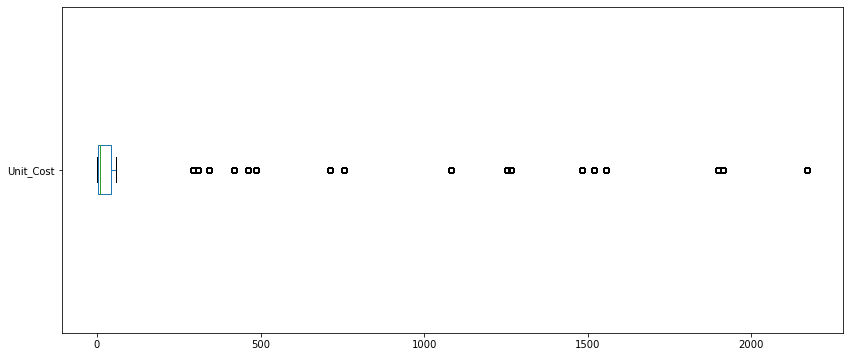

```python
#Box Plot
sales['Unit_Cost'].plot(kind = 'box', vert = False, figsize=(14,6))
```

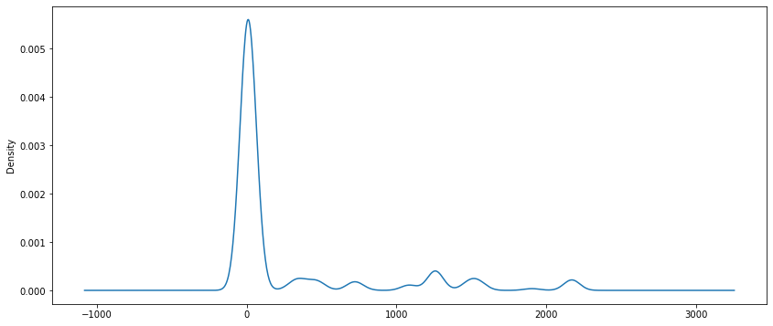

```python
#Density Plot
sales['Unit_Cost'].plot(kind = 'density', figsize=(14,6))
```

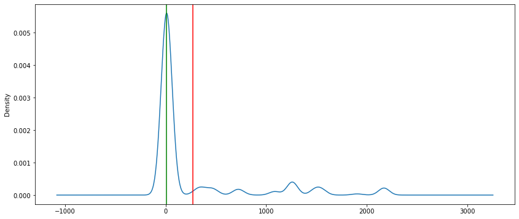

```python
ax = sales['Unit_Cost'].plot(kind = 'density', figsize = (14,6))
ax.axvline(sales['Unit_Cost'].mean(), color = 'red')
ax.axvline(sales['Unit_Cost'].median(), color = 'green')
```

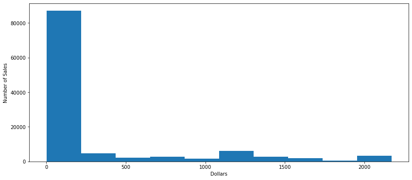

```python
ax = sales['Unit_Cost'].plot(kind='hist', figsize = (14,6))
ax.set_ylabel('Number of Sales')
ax.set_xlabel('Dollars')
```

```python
sales.head()
```

|  | Date | Day | Month | Year | Customer_Age | Age_Group | Customer_Gender | Country | State | Product_Category | Sub_Category | Product | Order_Quantity | Unit_Cost | Unit_Price | Profit | Cost | Revenue |
| --- | --- | --- | --- | --- | --- | --- | --- | --- | --- | --- | --- | --- | --- | --- | --- | --- | --- | --- |
| 0 | 2013-11-26 | 26 | November | 2013 | 19 | Youth (<25) | M | Canada | British Columbia | Accessories | Bike Racks | Hitch Rack - 4-Bike | 8 | 45 | 120 | 590 | 360 | 950 |
| 1 | 2015-11-26 | 26 | November | 2015 | 19 | Youth (<25) | M | Canada | British Columbia | Accessories | Bike Racks | Hitch Rack - 4-Bike | 8 | 45 | 120 | 590 | 360 | 950 |
| 2 | 2014-03-23 | 23 | March | 2014 | 49 | Adults (35-64) | M | Australia | New South Wales | Accessories | Bike Racks | Hitch Rack - 4-Bike | 23 | 45 | 120 | 1366 | 1035 | 2401 |
| 3 | 2016-03-23 | 23 | March | 2016 | 49 | Adults (35-64) | M | Australia | New South Wales | Accessories | Bike Racks | Hitch Rack - 4-Bike | 20 | 45 | 120 | 1188 | 900 | 2088 |
| 4 | 2014-05-15 | 15 | May | 2014 | 47 | Adults (35-64) | F | Australia | New South Wales | Accessories | Bike Racks | Hitch Rack - 4-Bike | 4 | 45 | 120 | 238 | 180 | 418 |

[figure not shown]

## Categorical analysis and visualization

> Analyzing Age_Group column

```python
sales['Age_Group'].value_counts()
```

```
Adults (35-64)          55824
Young Adults (25-34)    38654
Youth (<25)             17828
Seniors (64+)             730
Name: Age_Group, dtype: int64
```

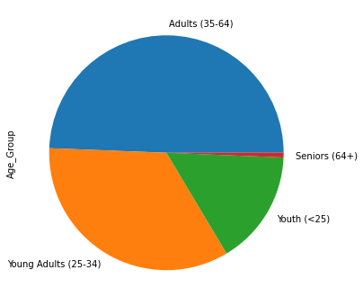

```python
sales['Age_Group'].value_counts().plot(kind='pie', figsize = (6,6))
```

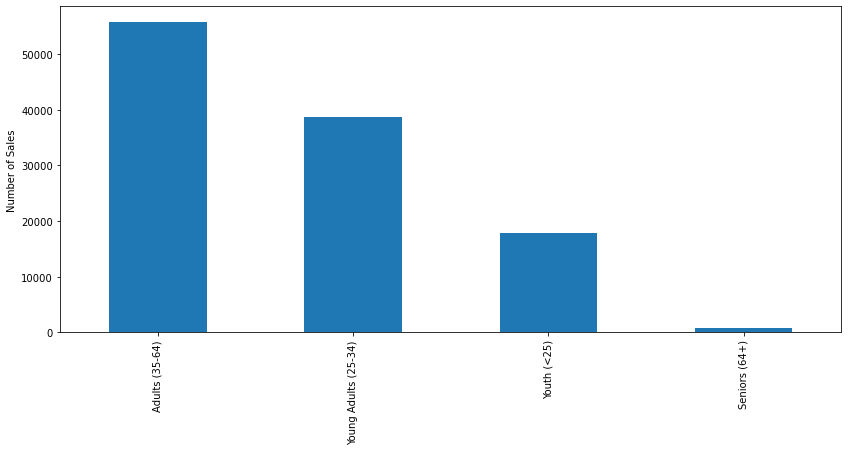

```python
ax = sales['Age_Group'].value_counts().plot(kind='bar', figsize=(14,6))
ax.set_ylabel('Number of Sales')
```

## Relationship between the columns

```python
corr = sales.corr()
corr
```

|  | Day | Year | Customer_Age | Order_Quantity | Unit_Cost | Unit_Price | Profit | Cost | Revenue |
| --- | --- | --- | --- | --- | --- | --- | --- | --- | --- |
| Day | 1.000000 | -0.007635 | -0.014296 | -0.002412 | 0.003133 | 0.003207 | 0.004623 | 0.003329 | 0.003853 |
| Year | -0.007635 | 1.000000 | 0.040994 | 0.123169 | -0.217575 | -0.213673 | -0.181525 | -0.215604 | -0.208673 |
| Customer_Age | -0.014296 | 0.040994 | 1.000000 | 0.026887 | -0.021374 | -0.020262 | 0.004319 | -0.016013 | -0.009326 |
| Order_Quantity | -0.002412 | 0.123169 | 0.026887 | 1.000000 | -0.515835 | -0.515925 | -0.238863 | -0.340382 | -0.312895 |
| Unit_Cost | 0.003133 | -0.217575 | -0.021374 | -0.515835 | 1.000000 | 0.997894 | 0.741020 | 0.829869 | 0.817865 |
| Unit_Price | 0.003207 | -0.213673 | -0.020262 | -0.515925 | 0.997894 | 1.000000 | 0.749870 | 0.826301 | 0.818522 |
| Profit | 0.004623 | -0.181525 | 0.004319 | -0.238863 | 0.741020 | 0.749870 | 1.000000 | 0.902233 | 0.956572 |
| Cost | 0.003329 | -0.215604 | -0.016013 | -0.340382 | 0.829869 | 0.826301 | 0.902233 | 1.000000 | 0.988758 |
| Revenue | 0.003853 | -0.208673 | -0.009326 | -0.312895 | 0.817865 | 0.818522 | 0.956572 | 0.988758 | 1.000000 |

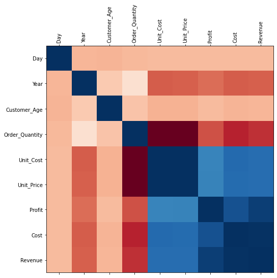

```python
fig = plt.figure(figsize=(8,8))
plt.matshow(corr, cmap='RdBu', fignum=fig.number)
plt.xticks(range(len(corr.columns)), corr.columns, rotation='vertical');
plt.yticks(range(len(corr.columns)), corr.columns);
```

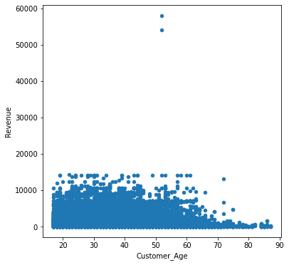

```python
sales.plot(kind='scatter', x='Customer_Age', y='Revenue', figsize=(6,6))
```

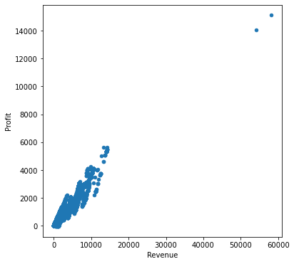

```python
sales.plot(kind='scatter', x='Revenue', y='Profit', figsize = (6,6))
```

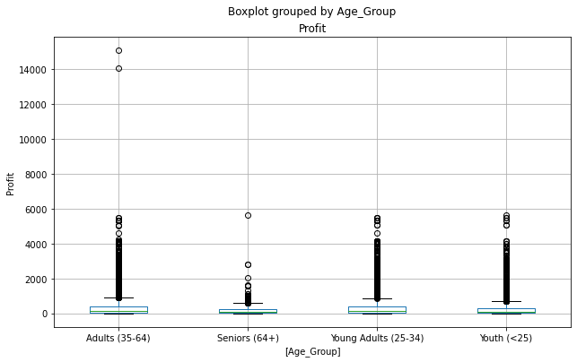

```python
ax = sales[['Profit', 'Age_Group']].boxplot(by='Age_Group', figsize=(10,6))
ax.set_ylabel('Profit')
```

```
Year                 AxesSubplot(0.125,0.536818;0.227941x0.343182)
Customer_Age      AxesSubplot(0.398529,0.536818;0.227941x0.343182)
Order_Quantity    AxesSubplot(0.672059,0.536818;0.227941x0.343182)
Unit_Cost               AxesSubplot(0.125,0.125;0.227941x0.343182)
Unit_Price           AxesSubplot(0.398529,0.125;0.227941x0.343182)
Profit               AxesSubplot(0.672059,0.125;0.227941x0.343182)
dtype: object
```

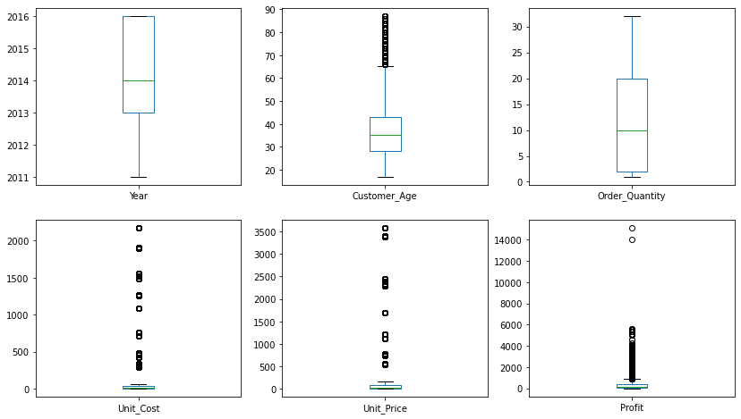

```python
boxplot_cols = ['Year', 'Customer_Age', 'Order_Quantity', 'Unit_Cost', 'Unit_Price', 'Profit']
sales[boxplot_cols].plot(kind='box', subplots=True, layout=(2,3), figsize = (14,8))
```

[figure not shown]

## Importing and Exporting Data

the main library in Python is MatPlotLib

We will:

> get data from public API

```python
import requests
import pandas as pd
```

```python
def get_historic_price(symbol, exchange='bitfinex', after='2018-08-01'):
    url = 'https://api.cryptowat.ch/markets/{exchange}/{symbol}usd/ohlc'.format(symbol=symbol, exchange=exchange)
    resp = requests.get(url, params = {
        'periods':'3600',
        'after': str(int(pd.Timestamp(after).timestamp()))
    })
    resp.raise_for_status()
    data = resp.json()
    df = pd.DataFrame(data['result']['3600'], columns=['CloseTime', 'OpenPrice', 'HighPrice', 'LowPrice', 'ClosePrice', 'Volume', 'NA'])
    df['CloseTime'] = pd.to_datetime(df['CloseTime'], unit='s')
    df.set_index('CloseTime', inplace=True)
    return df
```

### Pulling data from Bitcoin and Ether, for the last 7 days:

```python
last_week = (pd.Timestamp.now() - pd.offsets.Day(7))
last_week
```

```
Timestamp('2021-10-10 08:50:20.195372')
```

```python
btc = get_historic_price('btc', 'bitstamp', after=last_week)
```

```python
eth = get_historic_price('eth', 'bitstamp', after=last_week)
```

```python
btc.head()
```

| CloseTime | OpenPrice | HighPrice | LowPrice | ClosePrice | Volume | NA |
| --- | --- | --- | --- | --- | --- | --- |
| 2021-10-10 09:00:00 | 55677.60 | 55949.60 | 55540.03 | 55598.23 | 47.335142 | 2.637256e+06 |
| 2021-10-10 10:00:00 | 55606.07 | 55606.07 | 54832.00 | 54997.76 | 122.648492 | 6.758208e+06 |
| 2021-10-10 11:00:00 | 54953.82 | 55146.61 | 54716.72 | 55038.63 | 18.210722 | 1.001764e+06 |
| 2021-10-10 12:00:00 | 55027.38 | 55334.94 | 54848.99 | 55175.84 | 19.016533 | 1.046908e+06 |
| 2021-10-10 13:00:00 | 55192.07 | 55219.65 | 54764.18 | 54968.10 | 24.152811 | 1.327143e+06 |

```python
eth.head()
```

| CloseTime | OpenPrice | HighPrice | LowPrice | ClosePrice | Volume | NA |
| --- | --- | --- | --- | --- | --- | --- |
| 2021-10-10 09:00:00 | 3583.98 | 3597.25 | 3579.02 | 3585.70 | 254.942839 | 9.144188e+05 |
| 2021-10-10 10:00:00 | 3591.56 | 3593.56 | 3559.90 | 3574.37 | 467.736488 | 1.673581e+06 |
| 2021-10-10 11:00:00 | 3572.17 | 3585.47 | 3563.44 | 3570.54 | 172.060191 | 6.155289e+05 |
| 2021-10-10 12:00:00 | 3567.26 | 3575.58 | 3549.73 | 3566.75 | 130.352012 | 4.642714e+05 |
| 2021-10-10 13:00:00 | 3566.44 | 3567.32 | 3529.65 | 3545.88 | 248.664583 | 8.807648e+05 |

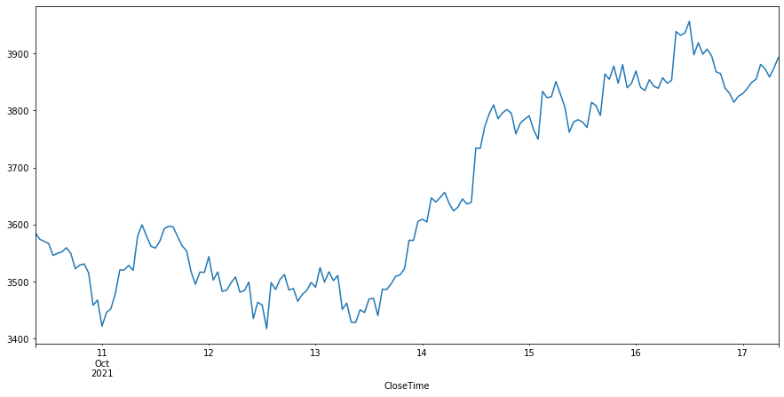

```python
eth['ClosePrice'].plot(figsize=(15,7))
```

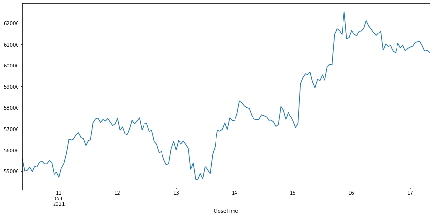

```python
btc['ClosePrice'].plot(figsize=(15,7))
```

[figure not shown]

### Dynamic plots with Bokeh

> Interactive plots that can be manipulated right from the browser!

```python
from bokeh.plotting import figure, output_file, show

from bokeh.io import output_notebook
```

```python
output_notebook()
```

```python
p1 = figure(x_axis_type='datetime', title='Crypto Prices', width=800)
p1.grid.grid_line_alpha=0.3
p1.xaxis.axis_label = 'Date'
p1.yaxis.axis_label = 'Price'

p1.line(btc.index, btc['ClosePrice'], color='#f2a900', legend='Bitcoin')

p1.legend.location = 'top_left'

show(p1)
```

```
BokehDeprecationWarning: 'legend' keyword is deprecated, use explicit 'legend_label', 'legend_field', or 'legend_group' keywords instead
```

[interactive chart not shown]

[figure not shown]

### Exporting to Excel

```python
# creating an excel writer, a component of the pandas package

writer = pd.ExcelWriter('cryptos.xlsx')
```

```python
#writing both our bitcoin and ether data as separate sheets
btc.to_excel(writer, sheet_name='Bitcoin')
```

```python
eth.to_excel(writer, sheet_name='Ether')
```

```python
writer.save()
```

[figure not shown]

## Introduction to NumPy

## Numpy Introduction

lets say you have a table with a variable Age (ranging from 0 to 120)

Another column is Dollars (range from 0-60billions)

> Even though they are integers (plain number) => they have different annotations, thus different requirements in storage size

We can do the maths of how many bits we need to store age:

2**7 = 128 => if we have 7 bits, we are going to store from 0 up to: 1 1 1 1 1 1 1 => this is equal to 127 in decimal + 0 = 128

So for the age, the memory we will be using is 7 bits per user

> > What if we have to use millions?

2**32 => ... with 32 bits, we can store that (depending on the data and the size => just an example here)

> What if you have the entire population of the earth? => every bit is going to be important, because it will take a ton of data

=> Numpy allows you to be very efficient in selecting the current number of bits ( 8 bits is 1 byte)

### Numpy is a library that has a very advanced numeric processing that allows you to select the number of bits to use from memory to process data

```python
# in numpy, you can create number and control the size it has in bits:
np.int8
```

```
numpy.int8
```

```python
np.int16
```

```
numpy.int16
```

## Numpy is an Array processing library

> 99% about constantly processing arrays

#### You cannot reply on advanced CPU directive and instructions for processing matrices in python

### With Numpy that changes, when you create an array

```
    => it will create the elements in contiguous positions in memory

        => they will only take the amount of memory that we said they're going to take

                => We can rely on a bunch of very efficient, low-level instructions from the CPU for matrix calculations
```

## Especially for Machine Learning, we need fast Array processing

### This all applies to floats

> Completely different representation, will explore it in the course

[figure not shown]

## NumPy Arrays

Major Contributions:

=> Efficient numeric computation with C primitives

=> Efficient collections with vectorized operations

=> An integrated and natural Linear Algebra API

=> A C API for connecting NumPy with libraries written in C, C++, or FORTRAN

```python
import sys

import numpy as np
```

```python
#Basic Arrays with Numpy

np.array([1,2,3,4])
```

```
array([1, 2, 3, 4])
```

```python
a = np.array([1,2,3,4])
b = np.array([0, .22, 1, 1.02,.5])
```

```python
a[0], a[1]
```

```
(1, 2)
```

```python
a[0:]
```

```
array([1, 2, 3, 4])
```

```python
#steps count:
a[::2]
```

```
array([1, 3])
```

```python
# first option, not memory efficient!
b[0], b[2], b[-1]
```

```
(0.0, 1.0, 0.5)
```

```python
#multi-indexing! much easier than referencing each element alone
# this will create a numpy array => faster for processing => more memory efficient
b[[0,2,-1]]
```

```
array([0. , 1. , 0.5])
```

[figure not shown]

## Array Types

```python
a.dtype
# notice that numPy automatically assigned memory for it
# the numPy library needs to know the type of the object you are storing
# You cant just store a string with a number within it => it will not be able to provide performance and optimizations for arrays that are not consistent in size!
```

```
dtype('int64')
```

```python
# b contains floats so numPy assigns a different type for it:
b.dtype
```

```
dtype('float64')
```

```python
# You can change the default:

np.array([1,2,3,4], dtype=np.float)
```

```
array([1., 2., 3., 4.])
```

```python
#string type
c = np.array(['a','b','c'])
c.dtype
```

```
dtype('<U1')
```

```python
# No point of storing this in numPy, just for visualization
d = np.array([{'a':1}, sys])
d.dtype
```

```
dtype('O')
```

## NumPy stores numbers, date, Booleans, but not a regular individual objects, as demonstrated above

## There is a valid way to store a string, it has its own type in NumPy, but not its primary use

[figure not shown]

## Dimensions and Shapes

NumPy has several Attributes and Functions to work with multi-dimensional arrays

> shape, ndim (number of dimensions), size

```python
# this is a 2D array: 2 rows and 3 columns:

A = np.array([[1,2,3],[4,5,6]])

A.shape
```

```
(2, 3)
```

```python
A.ndim
```

```
2
```

```python
A.size
```

```
6
```

```python
# Going one step further, creating B with 3D
# B in this case is a qube
B = np.array([[[12,11,10],[9,8,7]], [[6,5,4],[3,2,1]]])
print(f"<Details of B>\n\tType: {B.dtype}\n\tShape: {B.shape}\n\tNum of Dimentions: {B.ndim}\n\tSize: {B.size}")
```

[output not shown]

> If the dimensions don't match, it will return type object

> Be careful when creating by hand as dimensions must match

```
example below
```

```python
C = np.array([[[12,11,10],[9,8,7]],[[6,5,4]]])
print(f"THIS IS HOW THE RESULT WOULD LOOK LIKE IF DIMENSIONS DONT MATCH\n\t\t\t<Details of C>\n\tType: {C.dtype}\t**Notice how the returned type is object, because of uneven dimensions (not matching)\n\tShape: {C.shape}\n\tNum of Dimentions: {C.ndim}\n\tSize: {C.size}")
```

```
THIS IS HOW THE RESULT WOULD LOOK LIKE IF DIMENSIONS DONT MATCH
			<Details of C>
	Type: object	**Notice how the returned type is object, because of uneven dimensions (not matching)
	Shape: (2,)
	Num of Dimentions: 1
	Size: 2
```

```python
type(C[0])
```

```
list
```

[figure not shown]

## Indexing and Slicing of Matrices

```python
#Square matrix
A = np.array([[1,2,3],[4,5,6],[7,8,9]])
```

```python
print(f"\t\t\tSimilar to before, but accounting for multiple dimensions!\n=>A[1]: {A[1]}\n=>A[1][0]: {A[1][0]}\t\t**Selecting first element from second row\n=>A[1,0]: {A[1,0]}\t\t**same selection, only using multi dimensional selection of NumPy\n\t\t\t=> more memory efficient\n\t\t\t=>Remember! we are dealing on row and column levels\n=>A[:,:2]: {A[:,:2]}\t\t\t**Selecting all rows, but only first 2 columns\n=>A[:2,:2]: {A[:2,:2]}\n=>A[:2,2:]: {A[:2,2:]}\n=>A: {A}")
```

```
			Similar to before, but accounting for multiple dimensions!
=>A[1]: [4 5 6]
=>A[1][0]: 4		**Selecting first element from second row
=>A[1,0]: 4		**same selection, only using multi dimensional selection of NumPy
			=> more memory efficient
			=>Remember! we are dealing on row and column levels
=>A[:,:2]: [[1 2]
 [4 5]
 [7 8]]			**Selecting all rows, but only first 2 columns
=>A[:2,:2]: [[1 2]
 [4 5]]
=>A[:2,2:]: [[3]
 [6]]
=>A: [[1 2 3]
 [4 5 6]
 [7 8 9]]
```

```python
#Re-Assigning:
A[1] = np.array([10,10,10])
A
```

```
array([[ 1,  2,  3],
       [10, 10, 10],
       [ 7,  8,  9]])
```

```python
#this is an Expand operation => numPy will take care of expanding it to the selected array
A[2] = 99
A
```

```
array([[ 1,  2,  3],
       [10, 10, 10],
       [99, 99, 99]])
```

[figure not shown]

## Summary Statistics:

There are many operations you can perform on a multi dimensional Array and matrices

```python
print(f"=> A.sum(): {A.sum()}\n=> A.mean(): {A.mean()}\n=> A.std(): {A.std()}\n=> A.var(): {A.var()}")
```

```
=> A.sum(): 333
=> A.mean(): 37.0
=> A.std(): 43.96463225012679
=> A.var(): 1932.888888888889
```

## We can do this with axis as well:

```python
#sum of each column
A.sum(axis=0)
```

```
array([110, 111, 112])
```

```python
#sum of each row
A.sum(axis=1)
```

```
array([  6,  30, 297])
```

```python
print(f"A.mean(axis=0): {A.mean(axis=0)}\nA.std(axis=0):{A.std(axis=0)}\nA.std(axis=1): {A.std(axis=1)}")
```

```
A.mean(axis=0): [36.66666667 37.         37.33333333]
A.std(axis=0):[44.22920101 43.96210489 43.69846171]
A.std(axis=1): [0.81649658 0.         0.        ]
```

[figure not shown]

## Broadcasting and Vectorized operations:

> fundamental pieces in NumPy!

### Vectorized operations are operations performed between both arrays and arrays, and arrays and scalars, which are optimized to be extremely fast

```python
a = np.arange(4)
a
```

```
array([0, 1, 2, 3])
```

#### "a" did not change here

#### => NumPy is an immutable first library => Any operation performed on an array will not modify it, but it will return a new array

```python
print(f"Vectorized operations, applied on each element of the array:\n\t=> a+10 : {a+10}\n\t=> a*10: {a*10}")
a
```

```
Vectorized operations, applied on each element of the array:
	=> a+10 : [10 11 12 13]
	=> a*10: [ 0 10 20 30]
```

```
array([0, 1, 2, 3])
```

#### here, the array became mutable and it changed "a", no new array returned

```python
a+=100
a
```

```
array([100, 101, 102, 103])
```

```python
l = [0,1,2,3]
#list comprehension:
[i * 10 for i in l]
```

```
[0, 10, 20, 30]
```

```python
a = np.arange(4)
a
```

```
array([0, 1, 2, 3])
```

```python
b = np.array([10,10,10,10])
b
```

```
array([10, 10, 10, 10])
```

```python
print(f"vectorized operations can also be between arrays and arrays:\n\t=> a+b: {a+b}\n\t=> a*b: {a*b}")
```

```
vectorized operations can also be between arrays and arrays:
	=> a+b: [10 11 12 13]
	=> a*b: [ 0 10 20 30]
```

[figure not shown]

## Boolean Arrays:

> Also called masks

```python
a = np.arange(4)
a
```

```
array([0, 1, 2, 3])
```

```python
#here we are selecting the first and last elements in the array, like we did before
a[[0,-1]]
```

```
array([0, 3])
```

```python
#I want to select these elements, in this order, will only select whats specified as True
#Usually not going to write manually true or false, this is the result of Broadcasting a boolean operation, like in the upcoming example
a[[True, False, False, False]]
```

```
array([0])
```

```python
#Broadcasting a boolean operation
a >= 2
```

```
array([False, False,  True,  True])
```

```python
#selecting the elements that pass (match) the boolean condition
#we are filtering/selecting the array using this boolean
a[a >= 2]
```

```
array([2, 3])
```

```python
a.mean()
```

```
1.5
```

```python
a[a>a.mean()]
```

```
array([2, 3])
```

```python
#all the elements that are NOT greater than the mean
a[~(a>a.mean())]
```

```
array([0, 1])
```

```python
a[(a==0) | (a==1)]
```

```
array([0, 1])
```

```python
a[(a <= 2) & (a%2==0)]
```

```
array([0, 2])
```

```python
A = np.random.randint(100, size=(3,3))
A
```

```
array([[32, 60, 47],
       [ 3, 74, 80],
       [ 8, 67, 45]])
```

```python
A[np.array([[True,False,True],[False,True,False],[True,False,True]])]
```

```
array([32, 47, 74,  8, 45])
```

```python
A > 30
```

```
array([[ True,  True,  True],
       [False,  True,  True],
       [False,  True,  True]])
```

```python
A[A>30]
```

```
array([32, 60, 47, 74, 80, 67, 45])
```

[figure not shown]

## Linear Algebra:

#### NumPy already contains all the most important operations for Linear Algebra and already optimized with low level semantics => Extremely fast!

```python
A = np.array([[1,2,3],[4,5,6], [7,8,9]])
B = np.array([[6,5],[4,3],[2,1]])
#B.ndim
#A.ndim
```

```python
A.dot(B)
```

```
array([[20, 14],
       [56, 41],
       [92, 68]])
```

```python
A @ B
```

```
array([[20, 14],
       [56, 41],
       [92, 68]])
```

```python
B.T
```

```
array([[6, 4, 2],
       [5, 3, 1]])
```

```python
A
```

```
array([[1, 2, 3],
       [4, 5, 6],
       [7, 8, 9]])
```

```python
B.T @ A
```

```
array([[36, 48, 60],
       [24, 33, 42]])
```

#### Size of Objects in Memory

An integer in Python is larger than 24 bytes

```python
sys.getsizeof(1)
```

```
28
```

```python
#Larger numbers will even take more bytes to store them!
sys.getsizeof(10**100)
```

```
72
```

#### NumPy size is much smaller

```python
np.dtype(int).itemsize
```

```
8
```

```python
np.dtype(np.int8).itemsize
```

```
1
```

```python
np.dtype(float).itemsize
```

```
8
```

### Lists are even larger in Python!

```python
#A one element list:
sys.getsizeof([1])
```

```
64
```

### Meanwhile in NumPy

```python
np.array([1]).nbytes
```

```
8
```

## Performance is also important!

```python
l = list(range(1000))
```

```python
a = np.arange(1000)
```

```python
%time np.sum(a ** 2)
```

```
CPU times: user 2.22 ms, sys: 0 ns, total: 2.22 ms
Wall time: 2.24 ms
```

```
332833500
```

```python
%time sum([x ** 2 for x in l])
```

```
CPU times: user 474 µs, sys: 54 µs, total: 528 µs
Wall time: 535 µs
```

```
332833500
```

[figure not shown]

# Pandas

> Very mature library, primary and important for data analysis and data science

## Step 1: Getting the data from multiple sources (Databases, Excel files, CSV files, ...)

## Step 2: Processing the Data (combining, merging, doing different types of Analysis)

## Step 3: Visualizing the data with Pandas

## Step 4: Creating reports, simple statistical analysis, some ML with the help of other libraries

[figure not shown]

## Data Structures that Pandas has, how they work? How are the data structures processed?

## 1) Pandas Series:

To demonstrate, will analyse "The Group of Seven"

> Will use pandas.Series object

> Series are very similar to numpy arrays

```python
import pandas as pd
import numpy as np
```

```python
#In millions:
g7_pop = pd.Series([35.467,63.951,80.940,60.665,127.061, 64.511, 318.523])
g7_pop
#ordered sequence of elements, all indexed by a given index, although it looks a lot like a python list, but we there are a ton of difference
```

```
0     35.467
1     63.951
2     80.940
3     60.665
4    127.061
5     64.511
6    318.523
dtype: float64
```

#### Series can have a name to better document the purpose of the Series

```python
g7_pop.name = 'G7 Population in millions'
g7_pop
```

```
0     35.467
1     63.951
2     80.940
3     60.665
4    127.061
5     64.511
6    318.523
Name: G7 Population in millions, dtype: float64
```

```python
g7_pop.dtype
#all the numbers in this object will be of type float64, and can have specific names, unlike python lists that contain many types
```

```
dtype('float64')
```

```python
g7_pop.values
#notice that its backed by numpy arrays!
```

```
array([ 35.467,  63.951,  80.94 ,  60.665, 127.061,  64.511, 318.523])
```

```python
type(g7_pop.values)
```

```
numpy.ndarray
```

```python
g7_pop
```

```
0     35.467
1     63.951
2     80.940
3     60.665
4    127.061
5     64.511
6    318.523
Name: G7 Population in millions, dtype: float64
```

```python
g7_pop[0]
```

```
35.467
```

```python
g7_pop.index
#notice that series have start, stop and step index, in python list, we dont see it, in here, each element has an associated value with it in series.
#both are ordered sequence of elements, although, we can change the index of an element in a series
```

[output not shown]

```python
g7_pop.index = ['Canada','France','Germany', 'Italy', 'Japan', 'United Kingdom', 'United States',]
g7_pop
#now we cna reference the series with a perticular index, that has a meaningful name, unlike python dictionaries, series are ordered!
```

```
Canada             35.467
France             63.951
Germany            80.940
Italy              60.665
Japan             127.061
United Kingdom     64.511
United States     318.523
Name: G7 Population in millions, dtype: float64
```

```python
type(g7_pop.index)
```

```
pandas.core.indexes.base.Index
```

```python
type(g7_pop.values)
```

```
numpy.ndarray
```

### We can say that Series look like "ordered dictionaries". We can actually create Series out of dictionaries:

```python
pd.Series({'Canada': 35.467, 'France': 63.951, 'Germany': 80.940, 'Italy': 60.665, 'Japan': 127.061, 'United Kingdom': 644.511, 'United States': 318.523}, name = 'G7 Population in millions')
```

```
Canada             35.467
France             63.951
Germany            80.940
Italy              60.665
Japan             127.061
United Kingdom    644.511
United States     318.523
Name: G7 Population in millions, dtype: float64
```

```python
#indexing is now done by those indices:
pd.Series(g7_pop, index=['France', 'Germany', 'Italy', 'Spain'])
```

```
France     63.951
Germany    80.940
Italy      60.665
Spain         NaN
Name: G7 Population in millions, dtype: float64
```

[figure not shown]

## Pandas Indexing and Conditional Selection:

```python
# we can consult directly
g7_pop['Canada']
```

```
35.467
```

```python
g7_pop['United Kingdom']
```

```
64.511
```

```python
#Numeric positions can also be used with the iloc attribute
g7_pop.iloc[0]
```

```
35.467
```

```python
g7_pop.iloc[-1]
```

```
318.523
```

```python
#selecting multiple elements at once:
g7_pop[['Italy', 'France']]
#The result is another Series
```

```
Italy     60.665
France    63.951
Name: G7 Population in millions, dtype: float64
```

```python
#also sequential multi-indexing:
g7_pop.iloc[[0,1]]
```

```
Canada    35.467
France    63.951
Name: G7 Population in millions, dtype: float64
```

## IMPORTANT!!

## Series also support range or selection or slices, BUT there is a fundamental difference with Python

#### In Pyton, the upper limit of the slice is not returned

## In Series, the upper limit is included!

```python
g7_pop['Canada':'Italy']
#Notice how Italy is included in the returned result
```

```
Canada     35.467
France     63.951
Germany    80.940
Italy      60.665
Name: G7 Population in millions, dtype: float64
```

[figure not shown]

## Conditional Selection (Boolean Arrays):

> The same boolean array techniques that we saw applied to numpy arrays can be used for Pandas Series

## ~ : Not

## | : Or

## & : And

## All work with boolean selections

## Boolean Series, we can perform operations on top of Series:

```python
g7_pop
```

```
Canada             35.467
France             63.951
Germany            80.940
Italy              60.665
Japan             127.061
United Kingdom     64.511
United States     318.523
Name: G7 Population in millions, dtype: float64
```

```python
g7_pop > 70
```

```
Canada            False
France            False
Germany            True
Italy             False
Japan              True
United Kingdom    False
United States      True
Name: G7 Population in millions, dtype: bool
```

```python
g7_pop.mean()
```

```
107.30257142857144
```

```python
g7_pop[(g7_pop > g7_pop.mean() - g7_pop.std() / 2) | (g7_pop > g7_pop.mean() + g7_pop.std() / 2)]
```

```
France             63.951
Germany            80.940
Italy              60.665
Japan             127.061
United Kingdom     64.511
United States     318.523
Name: G7 Population in millions, dtype: float64
```

[figure not shown]

## Operations and Methods:

> Series also support vectorized operations and aggregation functions as NumPy

```python
g7_pop * 1_000_000
```

```
Canada             35467000.0
France             63951000.0
Germany            80940000.0
Italy              60665000.0
Japan             127061000.0
United Kingdom     64511000.0
United States     318523000.0
Name: G7 Population in millions, dtype: float64
```

```python
g7_pop.mean()
```

```
107.30257142857144
```

```python
np.log(g7_pop)
```

```
Canada            3.568603
France            4.158117
Germany           4.393708
Italy             4.105367
Japan             4.844667
United Kingdom    4.166836
United States     5.763695
Name: G7 Population in millions, dtype: float64
```

```python
g7_pop['France':'Italy'].mean()
```

```
68.51866666666666
```

[figure not shown]

## Boolean Arrays:

> Works the same way as NumPy

```python
g7_pop[(g7_pop > 80) | (g7_pop < 40)]
```

```
Canada            35.467
Germany           80.940
Japan            127.061
United States    318.523
Name: G7 Population in millions, dtype: float64
```

```python
g7_pop[(g7_pop>80) & (g7_pop<200)]
```

```
Germany     80.940
Japan      127.061
Name: G7 Population in millions, dtype: float64
```

[figure not shown]

## Modifying Series:

> Relatively simply, by index or sequential position or based on Boolean selection

## This will be extremely important when we are cleaning data!

```python
#by index:
g7_pop['Canada'] = 40.5
g7_pop
```

```
Canada             40.500
France             63.951
Germany            80.940
Italy              60.665
Japan             127.061
United Kingdom     64.511
United States     318.523
Name: G7 Population in millions, dtype: float64
```

```python
#sequential position
g7_pop.iloc[-1] = 500
g7_pop
```

```
Canada             40.500
France             63.951
Germany            80.940
Italy              60.665
Japan             127.061
United Kingdom     64.511
United States     500.000
Name: G7 Population in millions, dtype: float64
```

```python
#based on boolean selection
g7_pop[g7_pop < 70] = 99.99
g7_pop
```

```
Canada             99.990
France             99.990
Germany            80.940
Italy              99.990
Japan             127.061
United Kingdom     99.990
United States     500.000
Name: G7 Population in millions, dtype: float64
```

[figure not shown]

## Pandas DataFrames

> Pretty similar to excel table

```python
df = pd.DataFrame({
    'Population': [35.467,  63.951,  80.94 ,  60.665, 127.061,  64.511, 318.523],
    'GDP': [1785387, 2833687,3834343,34234432,454324,5342542,452354],
    'Surface Area': [452525,4351541,145154,4784,84676,45452,62565],
    'HDI': [0.965,0.856,0.932,0.843,0.998,0.891,0.786],
    'Continent': ['America', 'Europe','Europe','Europe', 'Asia', 'Europe', 'America']
}, columns = ['Population', 'GDP', 'Surface Area', 'HDI', 'Continent'])
```

```python
df
#notice how dataframes also have indexes => Pandas assigned a numeric, autoincremental index automaticcally to each "row" in our DataFrame
```

|  | Population | GDP | Surface Area | HDI | Continent |
| --- | --- | --- | --- | --- | --- |
| 0 | 35.467 | 1785387 | 452525 | 0.965 | America |
| 1 | 63.951 | 2833687 | 4351541 | 0.856 | Europe |
| 2 | 80.940 | 3834343 | 145154 | 0.932 | Europe |
| 3 | 60.665 | 34234432 | 4784 | 0.843 | Europe |
| 4 | 127.061 | 454324 | 84676 | 0.998 | Asia |
| 5 | 64.511 | 5342542 | 45452 | 0.891 | Europe |
| 6 | 318.523 | 452354 | 62565 | 0.786 | America |

```python
#since in our case, we know that each row represents a country, so we can re-assign the indexes that were provided automatically:

df.index = ['Canada','France','Germany', 'Italy', 'Japan', 'United Kingdom', 'United States',]
df
```

|  | Population | GDP | Surface Area | HDI | Continent |
| --- | --- | --- | --- | --- | --- |
| Canada | 35.467 | 1785387 | 452525 | 0.965 | America |
| France | 63.951 | 2833687 | 4351541 | 0.856 | Europe |
| Germany | 80.940 | 3834343 | 145154 | 0.932 | Europe |
| Italy | 60.665 | 34234432 | 4784 | 0.843 | Europe |
| Japan | 127.061 | 454324 | 84676 | 0.998 | Asia |
| United Kingdom | 64.511 | 5342542 | 45452 | 0.891 | Europe |
| United States | 318.523 | 452354 | 62565 | 0.786 | America |

## We can think of a dataFrame as a combination between multiple Series, 1 per column

```python
# you have several attributes that you cna consult (name of columns, index names,info(), size, shape, describe, dtypes, ...)
df.columns
```

```
Index(['Population', 'GDP', 'Surface Area', 'HDI', 'Continent'], dtype='object')
```

```python
df.index
```

```
Index(['Canada', 'France', 'Germany', 'Italy', 'Japan', 'United Kingdom',
       'United States'],
      dtype='object')
```

```python
#quick information about the structure of your dataFrame
df.info()
```

```
<class 'pandas.core.frame.DataFrame'>
Index: 7 entries, Canada to United States
Data columns (total 5 columns):
 #   Column        Non-Null Count  Dtype
---  ------        --------------  -----
 0   Population    7 non-null      float64
 1   GDP           7 non-null      int64
 2   Surface Area  7 non-null      int64
 3   HDI           7 non-null      float64
 4   Continent     7 non-null      object
dtypes: float64(2), int64(2), object(1)
memory usage: 336.0+ bytes
```

```python
df.size
```

```
35
```

```python
df.shape
```

```
(7, 5)
```

```python
# Similar to info, to check the structure of the dataframe => summary of the statistics of the dataframe
# This is for numeric columns only => they will have summary statistics for them
df.describe()
```

|  | Population | GDP | Surface Area | HDI |
| --- | --- | --- | --- | --- |
| count | 7.000000 | 7.000000e+00 | 7.000000e+00 | 7.000000 |
| mean | 107.302571 | 6.991010e+06 | 7.352424e+05 | 0.895857 |
| std | 97.249970 | 1.214324e+07 | 1.601607e+06 | 0.074156 |
| min | 35.467000 | 4.523540e+05 | 4.784000e+03 | 0.786000 |
| 25% | 62.308000 | 1.119856e+06 | 5.400850e+04 | 0.849500 |
| 50% | 64.511000 | 2.833687e+06 | 8.467600e+04 | 0.891000 |
| 75% | 104.000500 | 4.588442e+06 | 2.988395e+05 | 0.948500 |
| max | 318.523000 | 3.423443e+07 | 4.351541e+06 | 0.998000 |

```python
#Pandas, through NumPy, is automatically recognizing the correct type to assign to contents
df.dtypes
```

```
Population      float64
GDP               int64
Surface Area      int64
HDI             float64
Continent        object
dtype: object
```

```python
#Quick reference of the types
df.dtypes.value_counts()
```

```
int64      2
float64    2
object     1
dtype: int64
```

[figure not shown]

## Indexing, Selecting and Slicing DataFrames

> Individual columns in the DataFrame can be selected with regular indexing. Each column is represented as a Series:

```python
df
```

|  | Population | GDP | Surface Area | HDI | Continent |
| --- | --- | --- | --- | --- | --- |
| Canada | 35.467 | 1785387 | 452525 | 0.965 | America |
| France | 63.951 | 2833687 | 4351541 | 0.856 | Europe |
| Germany | 80.940 | 3834343 | 145154 | 0.932 | Europe |
| Italy | 60.665 | 34234432 | 4784 | 0.843 | Europe |
| Japan | 127.061 | 454324 | 84676 | 0.998 | Asia |
| United Kingdom | 64.511 | 5342542 | 45452 | 0.891 | Europe |
| United States | 318.523 | 452354 | 62565 | 0.786 | America |

```python
#Selecting the row by index:
df.loc['Canada']
```

```
Population       35.467
GDP             1785387
Surface Area     452525
HDI               0.965
Continent       America
Name: Canada, dtype: object
```

```python
#Selecting by Sequential position
df.iloc[-1]
```

```
Population      318.523
GDP              452354
Surface Area      62565
HDI               0.786
Continent       America
Name: United States, dtype: object
```

```python
#if not using loc or iloc, then you are selecting the entire column, as such:
df['Population']
```

```
Canada             35.467
France             63.951
Germany            80.940
Italy              60.665
Japan             127.061
United Kingdom     64.511
United States     318.523
Name: Population, dtype: float64
```

## In Summary, both loc and iloc, work in a horizontal way, selecting row, meanwhile if we dont use them and directly reference the column, then the result will be that column

## Always what's being returned is a Series

[figure not shown]

## Pandas Conditional Selection and Modifying DataFrames

```python
df
```

|  | Population | GDP | Surface Area | HDI | Continent |
| --- | --- | --- | --- | --- | --- |
| Canada | 35.467 | 1785387 | 452525 | 0.965 | America |
| France | 63.951 | 2833687 | 4351541 | 0.856 | Europe |
| Germany | 80.940 | 3834343 | 145154 | 0.932 | Europe |
| Italy | 60.665 | 34234432 | 4784 | 0.843 | Europe |
| Japan | 127.061 | 454324 | 84676 | 0.998 | Asia |
| United Kingdom | 64.511 | 5342542 | 45452 | 0.891 | Europe |
| United States | 318.523 | 452354 | 62565 | 0.786 | America |

```python
#Selecting all countries which population is greater than 70
df['Population'] > 70
```

```
Canada            False
France            False
Germany            True
Italy             False
Japan              True
United Kingdom    False
United States      True
Name: Population, dtype: bool
```

```python
df.loc[df['Population'] > 70]
```

|  | Population | GDP | Surface Area | HDI | Continent |
| --- | --- | --- | --- | --- | --- |
| Germany | 80.940 | 3834343 | 145154 | 0.932 | Europe |
| Japan | 127.061 | 454324 | 84676 | 0.998 | Asia |
| United States | 318.523 | 452354 | 62565 | 0.786 | America |

```python
#specifying column as well
df.loc[df['Population'] > 70, 'Population']
```

```
Germany           80.940
Japan            127.061
United States    318.523
Name: Population, dtype: float64
```

```python
#specifying multiple columns:
df.loc[df['Population'] > 70, ['Population', 'GDP']]
```

|  | Population | GDP |
| --- | --- | --- |
| Germany | 80.940 | 3834343 |
| Japan | 127.061 | 454324 |
| United States | 318.523 | 452354 |

[figure not shown]

## Dropping Stuff

> Opposite to the concept of selection

## Instead of pointing out which values you'd like to select, you could point out which ones you'd like to drop:

```python
df.drop('Canada')
```

|  | Population | GDP | Surface Area | HDI | Continent |
| --- | --- | --- | --- | --- | --- |
| France | 63.951 | 2833687 | 4351541 | 0.856 | Europe |
| Germany | 80.940 | 3834343 | 145154 | 0.932 | Europe |
| Italy | 60.665 | 34234432 | 4784 | 0.843 | Europe |
| Japan | 127.061 | 454324 | 84676 | 0.998 | Asia |
| United Kingdom | 64.511 | 5342542 | 45452 | 0.891 | Europe |
| United States | 318.523 | 452354 | 62565 | 0.786 | America |

```python
df.drop(['Canada', 'Japan'])
```

|  | Population | GDP | Surface Area | HDI | Continent |
| --- | --- | --- | --- | --- | --- |
| France | 63.951 | 2833687 | 4351541 | 0.856 | Europe |
| Germany | 80.940 | 3834343 | 145154 | 0.932 | Europe |
| Italy | 60.665 | 34234432 | 4784 | 0.843 | Europe |
| United Kingdom | 64.511 | 5342542 | 45452 | 0.891 | Europe |
| United States | 318.523 | 452354 | 62565 | 0.786 | America |

```python
#dropping columns:

df.drop(columns=['Population', 'HDI'])
```

|  | GDP | Surface Area | Continent |
| --- | --- | --- | --- |
| Canada | 1785387 | 452525 | America |
| France | 2833687 | 4351541 | Europe |
| Germany | 3834343 | 145154 | Europe |
| Italy | 34234432 | 4784 | Europe |
| Japan | 454324 | 84676 | Asia |
| United Kingdom | 5342542 | 45452 | Europe |
| United States | 452354 | 62565 | America |

### They have not-so recommended methods with axis, as demonstrated below

```python
df.drop(['Italy', 'Canada'], axis = 0)
```

|  | Population | GDP | Surface Area | HDI | Continent |
| --- | --- | --- | --- | --- | --- |
| France | 63.951 | 2833687 | 4351541 | 0.856 | Europe |
| Germany | 80.940 | 3834343 | 145154 | 0.932 | Europe |
| Japan | 127.061 | 454324 | 84676 | 0.998 | Asia |
| United Kingdom | 64.511 | 5342542 | 45452 | 0.891 | Europe |
| United States | 318.523 | 452354 | 62565 | 0.786 | America |

```python
df.drop(['Population', 'HDI'], axis = 1)
```

|  | GDP | Surface Area | Continent |
| --- | --- | --- | --- |
| Canada | 1785387 | 452525 | America |
| France | 2833687 | 4351541 | Europe |
| Germany | 3834343 | 145154 | Europe |
| Italy | 34234432 | 4784 | Europe |
| Japan | 454324 | 84676 | Asia |
| United Kingdom | 5342542 | 45452 | Europe |
| United States | 452354 | 62565 | America |

```python
df.drop(['Population', 'HDI'], axis = 'columns')
```

|  | GDP | Surface Area | Continent |
| --- | --- | --- | --- |
| Canada | 1785387 | 452525 | America |
| France | 2833687 | 4351541 | Europe |
| Germany | 3834343 | 145154 | Europe |
| Italy | 34234432 | 4784 | Europe |
| Japan | 454324 | 84676 | Asia |
| United Kingdom | 5342542 | 45452 | Europe |
| United States | 452354 | 62565 | America |

```python
df.drop(['Canada', 'Germany'], axis = 'rows')
```

|  | Population | GDP | Surface Area | HDI | Continent |
| --- | --- | --- | --- | --- | --- |
| France | 63.951 | 2833687 | 4351541 | 0.856 | Europe |
| Italy | 60.665 | 34234432 | 4784 | 0.843 | Europe |
| Japan | 127.061 | 454324 | 84676 | 0.998 | Asia |
| United Kingdom | 64.511 | 5342542 | 45452 | 0.891 | Europe |
| United States | 318.523 | 452354 | 62565 | 0.786 | America |

[figure not shown]

## Operations

## Broadcasting operations that we are going to do between the Series

```python
df[['Population', 'GDP']]
```

|  | Population | GDP |
| --- | --- | --- |
| Canada | 35.467 | 1785387 |
| France | 63.951 | 2833687 |
| Germany | 80.940 | 3834343 |
| Italy | 60.665 | 34234432 |
| Japan | 127.061 | 454324 |
| United Kingdom | 64.511 | 5342542 |
| United States | 318.523 | 452354 |

```python
df[['Population', 'GDP']] * 100
```

|  | Population | GDP |
| --- | --- | --- |
| Canada | 3546.7 | 178538700 |
| France | 6395.1 | 283368700 |
| Germany | 8094.0 | 383434300 |
| Italy | 6066.5 | 3423443200 |
| Japan | 12706.1 | 45432400 |
| United Kingdom | 6451.1 | 534254200 |
| United States | 31852.3 | 45235400 |

```python
df[['Population', 'GDP']] / 100
```

|  | Population | GDP |
| --- | --- | --- |
| Canada | 0.35467 | 17853.87 |
| France | 0.63951 | 28336.87 |
| Germany | 0.80940 | 38343.43 |
| Italy | 0.60665 | 342344.32 |
| Japan | 1.27061 | 4543.24 |
| United Kingdom | 0.64511 | 53425.42 |
| United States | 3.18523 | 4523.54 |

## Operations with Series work at a column level, broadcasting down the rows

```python
crisis = pd.Series([-1_000_000, -0.3], index=['GDP', 'HDI'])
```

```python
# Broadcasting Operations between Series (df and crises)
df[['GDP','HDI']] + crisis
```

|  | GDP | HDI |
| --- | --- | --- |
| Canada | 785387.0 | 0.665 |
| France | 1833687.0 | 0.556 |
| Germany | 2834343.0 | 0.632 |
| Italy | 33234432.0 | 0.543 |
| Japan | -545676.0 | 0.698 |
| United Kingdom | 4342542.0 | 0.591 |
| United States | -547646.0 | 0.486 |

[figure not shown]

## Modifying Data frames

> Remember, so far, we have been performing immutable operations

> The actual shape of our dataFrame and its contents are still the same

> We are not changing the existing dataFrame, rather creating a new one each one with immutable operations

> 99% of operations in Pandas is immutable, performing them will create new Series

## How to Modify the actual contents of the dataFrame?

## Very Simple and intuitive, You can add columns, or replace values for columns without issues

```python
#Adding new column:
langs = pd.Series(['French', 'German', 'Italian'], index = ['France', 'Germany', 'Italy'], name='Language')
```

```python
df['Language'] = langs
```

```python
df
```

|  | Population | GDP | Surface Area | HDI | Continent | Language |
| --- | --- | --- | --- | --- | --- | --- |
| Canada | 35.467 | 1785387 | 452525 | 0.965 | America | NaN |
| France | 63.951 | 2833687 | 4351541 | 0.856 | Europe | French |
| Germany | 80.940 | 3834343 | 145154 | 0.932 | Europe | German |
| Italy | 60.665 | 34234432 | 4784 | 0.843 | Europe | Italian |
| Japan | 127.061 | 454324 | 84676 | 0.998 | Asia | NaN |
| United Kingdom | 64.511 | 5342542 | 45452 | 0.891 | Europe | NaN |
| United States | 318.523 | 452354 | 62565 | 0.786 | America | NaN |

```python
# Replacing values per column

df['Language'] = 'English'
df
```

|  | Population | GDP | Surface Area | HDI | Continent | Language |
| --- | --- | --- | --- | --- | --- | --- |
| Canada | 35.467 | 1785387 | 452525 | 0.965 | America | English |
| France | 63.951 | 2833687 | 4351541 | 0.856 | Europe | English |
| Germany | 80.940 | 3834343 | 145154 | 0.932 | Europe | English |
| Italy | 60.665 | 34234432 | 4784 | 0.843 | Europe | English |
| Japan | 127.061 | 454324 | 84676 | 0.998 | Asia | English |
| United Kingdom | 64.511 | 5342542 | 45452 | 0.891 | Europe | English |
| United States | 318.523 | 452354 | 62565 | 0.786 | America | English |

```python
#Renaming Columns:
#notice these have no = sign, so they will not change the actual dataframe

df.rename(columns = {'HDI': 'Human Development Index', 'Annual Popcorn Consumption': 'APC'}, index = {'United States':'USA', 'United Kingdom':'UK','Argentina':'AR'})
#notice that values that do not exist in the df did not cause any problems
#These operations are immutable, the original df has not been changed
```

|  | Population | GDP | Surface Area | Human Development Index | Continent | Language |
| --- | --- | --- | --- | --- | --- | --- |
| Canada | 35.467 | 1785387 | 452525 | 0.965 | America | English |
| France | 63.951 | 2833687 | 4351541 | 0.856 | Europe | English |
| Germany | 80.940 | 3834343 | 145154 | 0.932 | Europe | English |
| Italy | 60.665 | 34234432 | 4784 | 0.843 | Europe | English |
| Japan | 127.061 | 454324 | 84676 | 0.998 | Asia | English |
| UK | 64.511 | 5342542 | 45452 | 0.891 | Europe | English |
| USA | 318.523 | 452354 | 62565 | 0.786 | America | English |

```python
df.rename(index=str.upper)
```

|  | Population | GDP | Surface Area | HDI | Continent | Language |
| --- | --- | --- | --- | --- | --- | --- |
| CANADA | 35.467 | 1785387 | 452525 | 0.965 | America | English |
| FRANCE | 63.951 | 2833687 | 4351541 | 0.856 | Europe | English |
| GERMANY | 80.940 | 3834343 | 145154 | 0.932 | Europe | English |
| ITALY | 60.665 | 34234432 | 4784 | 0.843 | Europe | English |
| JAPAN | 127.061 | 454324 | 84676 | 0.998 | Asia | English |
| UNITED KINGDOM | 64.511 | 5342542 | 45452 | 0.891 | Europe | English |
| UNITED STATES | 318.523 | 452354 | 62565 | 0.786 | America | English |

```python
df
```

|  | Population | GDP | Surface Area | HDI | Continent | Language |
| --- | --- | --- | --- | --- | --- | --- |
| Canada | 35.467 | 1785387 | 452525 | 0.965 | America | English |
| France | 63.951 | 2833687 | 4351541 | 0.856 | Europe | English |
| Germany | 80.940 | 3834343 | 145154 | 0.932 | Europe | English |
| Italy | 60.665 | 34234432 | 4784 | 0.843 | Europe | English |
| Japan | 127.061 | 454324 | 84676 | 0.998 | Asia | English |
| United Kingdom | 64.511 | 5342542 | 45452 | 0.891 | Europe | English |
| United States | 318.523 | 452354 | 62565 | 0.786 | America | English |

```python
df.rename(index = lambda x: x.lower())
```

|  | Population | GDP | Surface Area | HDI | Continent | Language |
| --- | --- | --- | --- | --- | --- | --- |
| canada | 35.467 | 1785387 | 452525 | 0.965 | America | English |
| france | 63.951 | 2833687 | 4351541 | 0.856 | Europe | English |
| germany | 80.940 | 3834343 | 145154 | 0.932 | Europe | English |
| italy | 60.665 | 34234432 | 4784 | 0.843 | Europe | English |
| japan | 127.061 | 454324 | 84676 | 0.998 | Asia | English |
| united kingdom | 64.511 | 5342542 | 45452 | 0.891 | Europe | English |
| united states | 318.523 | 452354 | 62565 | 0.786 | America | English |

```python
df
```

|  | Population | GDP | Surface Area | HDI | Continent | Language |
| --- | --- | --- | --- | --- | --- | --- |
| Canada | 35.467 | 1785387 | 452525 | 0.965 | America | English |
| France | 63.951 | 2833687 | 4351541 | 0.856 | Europe | English |
| Germany | 80.940 | 3834343 | 145154 | 0.932 | Europe | English |
| Italy | 60.665 | 34234432 | 4784 | 0.843 | Europe | English |
| Japan | 127.061 | 454324 | 84676 | 0.998 | Asia | English |
| United Kingdom | 64.511 | 5342542 | 45452 | 0.891 | Europe | English |
| United States | 318.523 | 452354 | 62565 | 0.786 | America | English |

## Dropping Columns:

```python
df.drop(columns = 'Language', inplace=True)
```

```python
df
```

|  | Population | GDP | Surface Area | HDI | Continent |
| --- | --- | --- | --- | --- | --- |
| Canada | 35.467 | 1785387 | 452525 | 0.965 | America |
| France | 63.951 | 2833687 | 4351541 | 0.856 | Europe |
| Germany | 80.940 | 3834343 | 145154 | 0.932 | Europe |
| Italy | 60.665 | 34234432 | 4784 | 0.843 | Europe |
| Japan | 127.061 | 454324 | 84676 | 0.998 | Asia |
| United Kingdom | 64.511 | 5342542 | 45452 | 0.891 | Europe |
| United States | 318.523 | 452354 | 62565 | 0.786 | America |

## Adding Values:

```python
df.append(pd.Series({'Population':3, 'GDP':5}, name='China'))
#Append returns a new DataFrame
```

|  | Population | GDP | Surface Area | HDI | Continent |
| --- | --- | --- | --- | --- | --- |
| Canada | 35.467 | 1785387.0 | 452525.0 | 0.965 | America |
| France | 63.951 | 2833687.0 | 4351541.0 | 0.856 | Europe |
| Germany | 80.940 | 3834343.0 | 145154.0 | 0.932 | Europe |
| Italy | 60.665 | 34234432.0 | 4784.0 | 0.843 | Europe |
| Japan | 127.061 | 454324.0 | 84676.0 | 0.998 | Asia |
| United Kingdom | 64.511 | 5342542.0 | 45452.0 | 0.891 | Europe |
| United States | 318.523 | 452354.0 | 62565.0 | 0.786 | America |
| China | 3.000 | 5.0 | NaN | NaN | NaN |

```python
df
```

|  | Population | GDP | Surface Area | HDI | Continent |
| --- | --- | --- | --- | --- | --- |
| Canada | 35.467 | 1785387 | 452525 | 0.965 | America |
| France | 63.951 | 2833687 | 4351541 | 0.856 | Europe |
| Germany | 80.940 | 3834343 | 145154 | 0.932 | Europe |
| Italy | 60.665 | 34234432 | 4784 | 0.843 | Europe |
| Japan | 127.061 | 454324 | 84676 | 0.998 | Asia |
| United Kingdom | 64.511 | 5342542 | 45452 | 0.891 | Europe |
| United States | 318.523 | 452354 | 62565 | 0.786 | America |

```python
#we can use drop to just remove a row by index:
df.drop('Japan', inplace=True)
```

```python
df
```

|  | Population | GDP | Surface Area | HDI | Continent |
| --- | --- | --- | --- | --- | --- |
| Canada | 35.467 | 1785387 | 452525 | 0.965 | America |
| France | 63.951 | 2833687 | 4351541 | 0.856 | Europe |
| Germany | 80.940 | 3834343 | 145154 | 0.932 | Europe |
| Italy | 60.665 | 34234432 | 4784 | 0.843 | Europe |
| United Kingdom | 64.511 | 5342542 | 45452 | 0.891 | Europe |
| United States | 318.523 | 452354 | 62565 | 0.786 | America |

## More Radical Index Changes

```python
df.reset_index()
```

|  | index | Population | GDP | Surface Area | HDI | Continent |
| --- | --- | --- | --- | --- | --- | --- |
| 0 | Canada | 35.467 | 1785387 | 452525 | 0.965 | America |
| 1 | France | 63.951 | 2833687 | 4351541 | 0.856 | Europe |
| 2 | Germany | 80.940 | 3834343 | 145154 | 0.932 | Europe |
| 3 | Italy | 60.665 | 34234432 | 4784 | 0.843 | Europe |
| 4 | United Kingdom | 64.511 | 5342542 | 45452 | 0.891 | Europe |
| 5 | United States | 318.523 | 452354 | 62565 | 0.786 | America |

```python
df
```

|  | Population | GDP | Surface Area | HDI | Continent |
| --- | --- | --- | --- | --- | --- |
| Canada | 35.467 | 1785387 | 452525 | 0.965 | America |
| France | 63.951 | 2833687 | 4351541 | 0.856 | Europe |
| Germany | 80.940 | 3834343 | 145154 | 0.932 | Europe |
| Italy | 60.665 | 34234432 | 4784 | 0.843 | Europe |
| United Kingdom | 64.511 | 5342542 | 45452 | 0.891 | Europe |
| United States | 318.523 | 452354 | 62565 | 0.786 | America |

```python
df.set_index('Population')
```

| Population | GDP | Surface Area | HDI | Continent |
| --- | --- | --- | --- | --- |
| 35.467 | 1785387 | 452525 | 0.965 | America |
| 63.951 | 2833687 | 4351541 | 0.856 | Europe |
| 80.940 | 3834343 | 145154 | 0.932 | Europe |
| 60.665 | 34234432 | 4784 | 0.843 | Europe |
| 64.511 | 5342542 | 45452 | 0.891 | Europe |
| 318.523 | 452354 | 62565 | 0.786 | America |

```python
df
```

|  | Population | GDP | Surface Area | HDI | Continent |
| --- | --- | --- | --- | --- | --- |
| Canada | 35.467 | 1785387 | 452525 | 0.965 | America |
| France | 63.951 | 2833687 | 4351541 | 0.856 | Europe |
| Germany | 80.940 | 3834343 | 145154 | 0.932 | Europe |
| Italy | 60.665 | 34234432 | 4784 | 0.843 | Europe |
| United Kingdom | 64.511 | 5342542 | 45452 | 0.891 | Europe |
| United States | 318.523 | 452354 | 62565 | 0.786 | America |

[figure not shown]

## Creating Columns from Other Columns

```python
df[['Population', 'GDP']]
```

|  | Population | GDP |
| --- | --- | --- |
| Canada | 35.467 | 1785387 |
| France | 63.951 | 2833687 |
| Germany | 80.940 | 3834343 |
| Italy | 60.665 | 34234432 |
| United Kingdom | 64.511 | 5342542 |
| United States | 318.523 | 452354 |

```python
df['GDP'] / df['Population']
```

```
Canada             50339.385908
France             44310.284437
Germany            47372.658760
Italy             564319.327454
United Kingdom     82815.984871
United States       1420.161181
dtype: float64
```

```python
df['GDP Per Capita'] = df['GDP'] / df['Population']
```

```python
df
```

|  | Population | GDP | Surface Area | HDI | Continent | GDP Per Capita |
| --- | --- | --- | --- | --- | --- | --- |
| Canada | 35.467 | 1785387 | 452525 | 0.965 | America | 50339.385908 |
| France | 63.951 | 2833687 | 4351541 | 0.856 | Europe | 44310.284437 |
| Germany | 80.940 | 3834343 | 145154 | 0.932 | Europe | 47372.658760 |
| Italy | 60.665 | 34234432 | 4784 | 0.843 | Europe | 564319.327454 |
| United Kingdom | 64.511 | 5342542 | 45452 | 0.891 | Europe | 82815.984871 |
| United States | 318.523 | 452354 | 62565 | 0.786 | America | 1420.161181 |

[figure not shown]

## Reading External Data and Plotting

## Pandas can easily read data stored in different file formats like CSV, JSON, XML or even excel.

## Parsing the data always involves specifying the correct structure, encoding and other details.

## The read_csv method reads CSV files and accepts many parameters!

> don't worry about remembering every single parameter on the top of your head, research is your best friend Checkout:

## => [Pandas Documentation](https://pandas.pydata.org/docs/)

[figure not shown]

```python
import numpy as np

import pandas as pd

import matplotlib.pyplot as plt

%matplotlib inline
```

```python
#Notice how many parameters it accepts!
pd.read_csv
```

```
<function pandas.io.parsers.read_csv(filepath_or_buffer: Union[ForwardRef('PathLike[str]'), str, IO[~T], io.RawIOBase, io.BufferedIOBase, io.TextIOBase, _io.TextIOWrapper, mmap.mmap], sep=<object object at 0x7ffb18d55bd0>, delimiter=None, header='infer', names=None, index_col=None, usecols=None, squ…
```

```python
#A better look at the parameters:
pd.read_csv?
```

[output not shown]

[output cut: 308 more lines]

[output not shown]

```python
df = pd.read_csv('btc-market-price.csv')
```

```python
df.head()
```

|  | 2017-04-02 00:00:00 | 1099.169125 |
| --- | --- | --- |
| 0 | 2017-04-03 00:00:00 | 1141.813000 |
| 1 | 2017-04-04 00:00:00 | 1141.600363 |
| 2 | 2017-04-05 00:00:00 | 1133.079314 |
| 3 | 2017-04-06 00:00:00 | 1196.307937 |
| 4 | 2017-04-07 00:00:00 | 1190.454250 |

## The CSV we're reading has only two columns: timestamp and price.

## It doesn't have a header

## It contains whitespace

## It has values seperated by commas

## Pandas automatically assigned the first row of data as headers, which is incorrect!

## We can overwrite this behavior with the header parameter as such:

```python
df = pd.read_csv('btc-market-price.csv', header=None)
df.head()
```

|  | 0 | 1 |
| --- | --- | --- |
| 0 | 2017-04-02 00:00:00 | 1099.169125 |
| 1 | 2017-04-03 00:00:00 | 1141.813000 |
| 2 | 2017-04-04 00:00:00 | 1141.600363 |
| 3 | 2017-04-05 00:00:00 | 1133.079314 |
| 4 | 2017-04-06 00:00:00 | 1196.307937 |

## We can then set the name of each column explicitly by setting the df.columns attribute:

```python
df.columns = ['Timestamp', 'Price']
df.head()
```

|  | Timestamp | Price |
| --- | --- | --- |
| 0 | 2017-04-02 00:00:00 | 1099.169125 |
| 1 | 2017-04-03 00:00:00 | 1141.813000 |
| 2 | 2017-04-04 00:00:00 | 1141.600363 |
| 3 | 2017-04-05 00:00:00 | 1133.079314 |
| 4 | 2017-04-06 00:00:00 | 1196.307937 |

```python
df.shape
#365 rows & 2 columns
```

```
(365, 2)
```

```python
df.info()
#notice, Price dtype is float64 which is correct, but Timestamp is showing as an object!
```

```
<class 'pandas.core.frame.DataFrame'>
RangeIndex: 365 entries, 0 to 364
Data columns (total 2 columns):
 #   Column     Non-Null Count  Dtype
---  ------     --------------  -----
 0   Timestamp  365 non-null    object
 1   Price      365 non-null    float64
dtypes: float64(1), object(1)
memory usage: 5.8+ KB
```

```python
#we can also use the df.tail() to checkout the end rows
df.tail()
```

|  | Timestamp | Price |
| --- | --- | --- |
| 360 | 2018-03-28 00:00:00 | 7960.380000 |
| 361 | 2018-03-29 00:00:00 | 7172.280000 |
| 362 | 2018-03-30 00:00:00 | 6882.531667 |
| 363 | 2018-03-31 00:00:00 | 6935.480000 |
| 364 | 2018-04-01 00:00:00 | 6794.105000 |

```python
#specifying is possible:
df.head(10)
```

|  | Timestamp | Price |
| --- | --- | --- |
| 0 | 2017-04-02 00:00:00 | 1099.169125 |
| 1 | 2017-04-03 00:00:00 | 1141.813000 |
| 2 | 2017-04-04 00:00:00 | 1141.600363 |
| 3 | 2017-04-05 00:00:00 | 1133.079314 |
| 4 | 2017-04-06 00:00:00 | 1196.307937 |
| 5 | 2017-04-07 00:00:00 | 1190.454250 |
| 6 | 2017-04-08 00:00:00 | 1181.149838 |
| 7 | 2017-04-09 00:00:00 | 1208.800500 |
| 8 | 2017-04-10 00:00:00 | 1207.744875 |
| 9 | 2017-04-11 00:00:00 | 1226.617037 |

```python
df.tail(2)
```

|  | Timestamp | Price |
| --- | --- | --- |
| 363 | 2018-03-31 00:00:00 | 6935.480 |
| 364 | 2018-04-01 00:00:00 | 6794.105 |

```python
df.dtypes
#timestamp was not properly parsed as a date, it was parsed as an object
```

```
Timestamp     object
Price        float64
dtype: object
```

## We can perform a vectorized operation to parse all the Timestamp values as Datetime objects:

```python
pd.to_datetime(df['Timestamp']).head()
```

```
0   2017-04-02
1   2017-04-03
2   2017-04-04
3   2017-04-05
4   2017-04-06
Name: Timestamp, dtype: datetime64[ns]
```

```python
#nothing changed because of immutability, we need to re-assign the timestamp column with the parsed values!
df.dtypes
```

```
Timestamp     object
Price        float64
dtype: object
```

```python
df['Timestamp'] = pd.to_datetime(df['Timestamp'])
df.dtypes
#Now it worked!
```

```
Timestamp    datetime64[ns]
Price               float64
dtype: object
```

```python
df.head()
```

|  | Timestamp | Price |
| --- | --- | --- |
| 0 | 2017-04-02 | 1099.169125 |
| 1 | 2017-04-03 | 1141.813000 |
| 2 | 2017-04-04 | 1141.600363 |
| 3 | 2017-04-05 | 1133.079314 |
| 4 | 2017-04-06 | 1196.307937 |

## The timestamp looks a lot like the index of this DataFrame

## We can change the autoincremental ID generated by pandas and use the Timestamp DS column as the index

```python
df.set_index('Timestamp', inplace=True)
```

```python
df.head()
```

| Timestamp | Price |
| --- | --- |
| 2017-04-02 | 1099.169125 |
| 2017-04-03 | 1141.813000 |
| 2017-04-04 | 1141.600363 |
| 2017-04-05 | 1133.079314 |
| 2017-04-06 | 1196.307937 |

```python
#now we can do this to get the price of Bitcoin at a certain Timestamp, because it is the index
df.loc['2017-09-29']
```

```
Price    4193.574667
Name: 2017-09-29 00:00:00, dtype: float64
```

[figure not shown]

## Putting Everything Together

> What happens when we want to turn this into an automated script?

## The read_csv method is very powerful, that it lets us do everything so far in just one call of the read_csv method!

```python
#Here's what we did so far:

df = pd.read_csv('btc-market-price.csv', header=None)
df.columns = ['Timestamp', 'Price']
df['Timestamp'] = pd.to_datetime(df['Timestamp'])
df.set_index('Timestamp', inplace=True)
```

```python
df.head()
```

| Timestamp | Price |
| --- | --- |
| 2017-04-02 | 1099.169125 |
| 2017-04-03 | 1141.813000 |
| 2017-04-04 | 1141.600363 |
| 2017-04-05 | 1133.079314 |
| 2017-04-06 | 1196.307937 |

## The read_csv method is very powerful, that it lets us do everything so far in just one call of the read_csv method!

```python
df = pd.read_csv('btc-market-price.csv', header=None, names=['Timestamp','Price'], index_col=0, parse_dates=True)
df.head()
#same result, just one line of code
# we specified that the first col will be the index of the dataframe and all the rest inside the read_csv
```

| Timestamp | Price |
| --- | --- |
| 2017-04-02 | 1099.169125 |
| 2017-04-03 | 1141.813000 |
| 2017-04-04 | 1141.600363 |
| 2017-04-05 | 1133.079314 |
| 2017-04-06 | 1196.307937 |

[figure not shown]

## Plotting Basics:

## Pandas Integrates with Matplotlib.pyplot's interface.

## Creating a plot is as simple as:

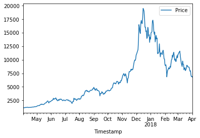

```python
df.plot()
```

## Behind the scenes, its using matplotlib.pyplot's inteface

## similar plot can be created with the plt.plot() function:

> plt.plot() accepts many parameters, but the first 2 ones are the most important ones: The values of the X and Y axes

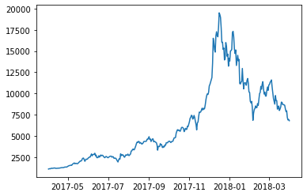

```python
plt.plot(df.index, df['Price'])
```

```python
x = np.arange(-10,11)
x
```

```
array([-10,  -9,  -8,  -7,  -6,  -5,  -4,  -3,  -2,  -1,   0,   1,   2,
         3,   4,   5,   6,   7,   8,   9,  10])
```

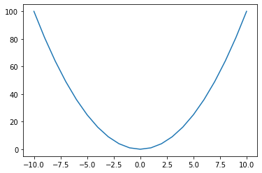

```python
plt.plot(x, x**2)
```

## We are using matplotlib's global API, which is horrible, but its the most popular one

## Will learn later how to use the OOP API which will make our work much easier!

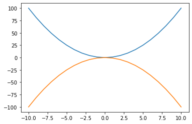

```python
plt.plot(x, x**2)
plt.plot(x, -1*(x**2))
```

## Each plt function alters the global state. If you want to set settings of your plot:

## Use plt.figure function

## Others like plt.title keep altering the global plot:

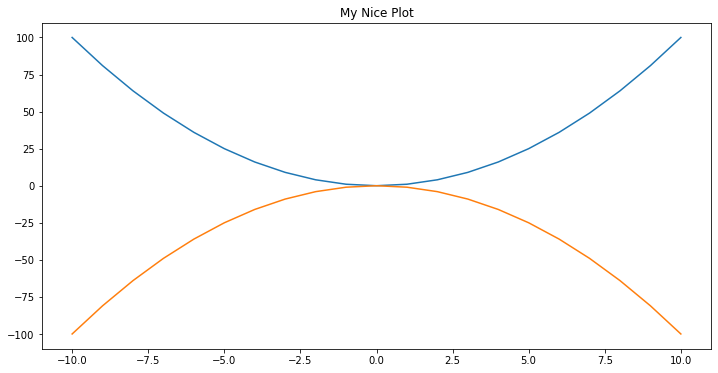

```python
plt.figure(figsize=(12,6))
plt.plot(x, x**2)
plt.plot(x, -1 * (x**2))

plt.title('My Nice Plot')
```

## Some of the arguments in plt.figure and plt.plot are available in the pandas' plot interface:

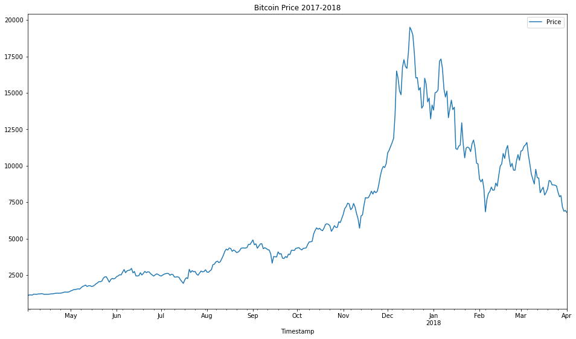

```python
df.plot(figsize=(16, 9), title='Bitcoin Price 2017-2018')
```

## A more Challenging parsing

lets add Ether prices to our DataFrame, it will need cleaning up

```python
eth = pd.read_csv('eth-price.csv')

print(eth.dtypes)
eth.head()
```

```
Date(UTC)         object
UnixTimeStamp      int64
Value            float64
dtype: object
```

|  | Date(UTC) | UnixTimeStamp | Value |
| --- | --- | --- | --- |
| 0 | 4/2/2017 | 1491091200 | 48.55 |
| 1 | 4/3/2017 | 1491177600 | 44.13 |
| 2 | 4/4/2017 | 1491264000 | 44.43 |
| 3 | 4/5/2017 | 1491350400 | 44.90 |
| 4 | 4/6/2017 | 1491436800 | 43.23 |

## It has a value column, which represents the price. A Date(UTC) one that has a string representing dates. And also a UnixTimeStamp date representing the datetime in unix timestamp format

```python
eth = pd.read_csv('eth-price.csv', parse_dates=True)
print(eth.dtypes)
```

```
Date(UTC)         object
UnixTimeStamp      int64
Value            float64
dtype: object
```